# p8105_hw1_gw2383

Guojing Wu

## Problem 1

### step 1

**We start with creating a data frame:**

```r
prob1_df = tibble (
  vec_runif = runif(10, min = 0, max = 5),
  vec_logical = c(vec_runif > 2), # judge the vec_runif and reture True or False
  vec_char = c("p8105", "data", "science", "is", "great",
               "my", "name", "is", "guojing", "wu"),
  vec_factor = factor(c(1, 2, 3, 1, 2, 3, 1, 2, 3, 1))
)

# show the result
prob1_df
```

```
## # A tibble: 10 x 4
##    vec_runif vec_logical vec_char vec_factor
##        <dbl> <lgl>       <chr>    <fct>
##  1     1.75  FALSE       p8105    1
##  2     4.05  TRUE        data     2
##  3     0.258 FALSE       science  3
##  4     2.69  TRUE        is       1
##  5     1.74  FALSE       great    2
##  6     3.70  TRUE        my       3
##  7     1.08  FALSE       name     1
##  8     2.65  TRUE        is       2
##  9     0.397 FALSE       guojing  3
## 10     2.91  TRUE        wu       1
```

### step 2

**Calculate the mean of each variable**

```r
mean(prob1_df$vec_runif)
```

```
## [1] 2.122934
```

- Since vec_runif is numerical, we can calculate the mean value.

```r
mean(prob1_df$vec_logical)
```

```
## [1] 0.5
```

- R regard the logical value true as 1 and false as 0, so we can also calculate the mean value.

```r
mean(prob1_df$vec_char)
```

```
## [1] NA
```

- The characters are not numerical, so we can’t calculate mean value.

```r
mean(prob1_df$vec_factor)
```

```
## [1] NA
```

- The characters are not numerical, so we can’t calculate mean value.

### step 3

**Applies the `as.numeric` function to the logical, character, and factor variables.**

```r
as.numeric(prob1_df$vec_logical)
as.numeric(prob1_df$vec_char)
as.numeric(prob1_df$vec_factor)
```

[output not shown]

What happened are:

- Logical vector is converted to `0` (for false) and `1` (for true)
- Character vector is converted to `NA`
- Factors is converted to numbers correspondingly

* Notice: my factor vector is generated from a numerical vector, so here we disscuss another type of situation: what will happen if the factor vector is generated from a character vector.

```r
vec_factor_2 = factor(c("a", "a", "b", "b", "b", "c", "d", "e", "f", "g"))
as.numeric(vec_factor_2)
```

```
##  [1] 1 1 2 2 2 3 4 5 6 7
```

Here we see that characters also been converted to numbers! And the same characters designated the same numbers.

### step 4

**Convert character variable from character to factor to numeric:**

```r
prob1_df$vec_char %>%
  as.factor() %>%
  as.numeric()
```

```
##  [1] 7 1 8 4 2 5 6 4 3 9
```

**Convert factor variable from factor to character to numeric:**

```r
prob1_df$vec_factor %>%
  as.character() %>%
  as.numeric()
```

```
##  [1] 1 2 3 1 2 3 1 2 3 1
```

Here we can see that factor vector is first converted to character, and since all the factors are numerical, they are actually converted from factor (like `1`) into the same word but in type of character (like `"1"`). Then they are converted into number accordingly.

* Notice: here we disscuss another type of situation: what will happen if the factor vector is generated from a character vector.

```r
vec_factor_2 %>%
  as.character() %>%
  as.numeric()
```

```
##  [1] NA NA NA NA NA NA NA NA NA NA
```

Here we see that the string-based factor first converted to character correspondingly, but then `NA` produced by converting characters to numbers.

## Problem 2

### step 1

**Create a data.frame:**

```r
prob2_df = tibble(
  x = rnorm(1000),
  y = rnorm(1000),
  vec_logical = ((x + y) >0),  # judge if x + y > 0 and return TRUE or FALSE accordingly
  vec_num = as.numeric(vec_logical),
  vec_factor = as.factor(vec_logical)
)
```

### step 3

**Make scatterplots using `ggplot2`:**

- Make a scatterplot of `y` vs `x`, color points using the logical variable.

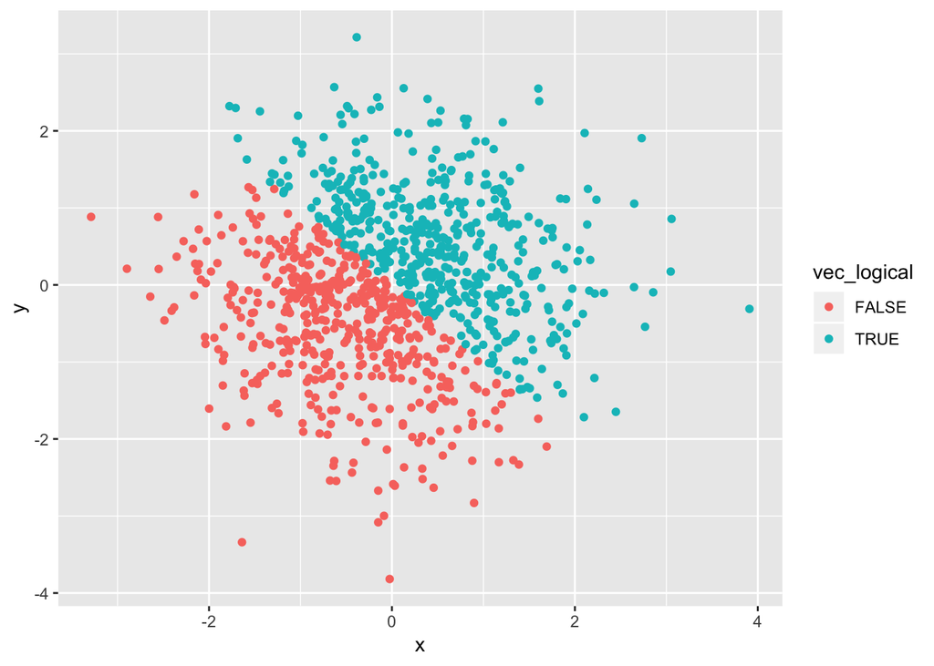

```r
scat_logical = ggplot(prob2_df, aes(x = x, y = y)) + # data parameters
  geom_point(aes(color = vec_logical))  # aesthetic paramters
scat_logical
```

Since the color parameters only have two logical values, ggplot only assign them with two colors.

- Make a scatterplot of `y` vs `x`, color points using the numerical variable.

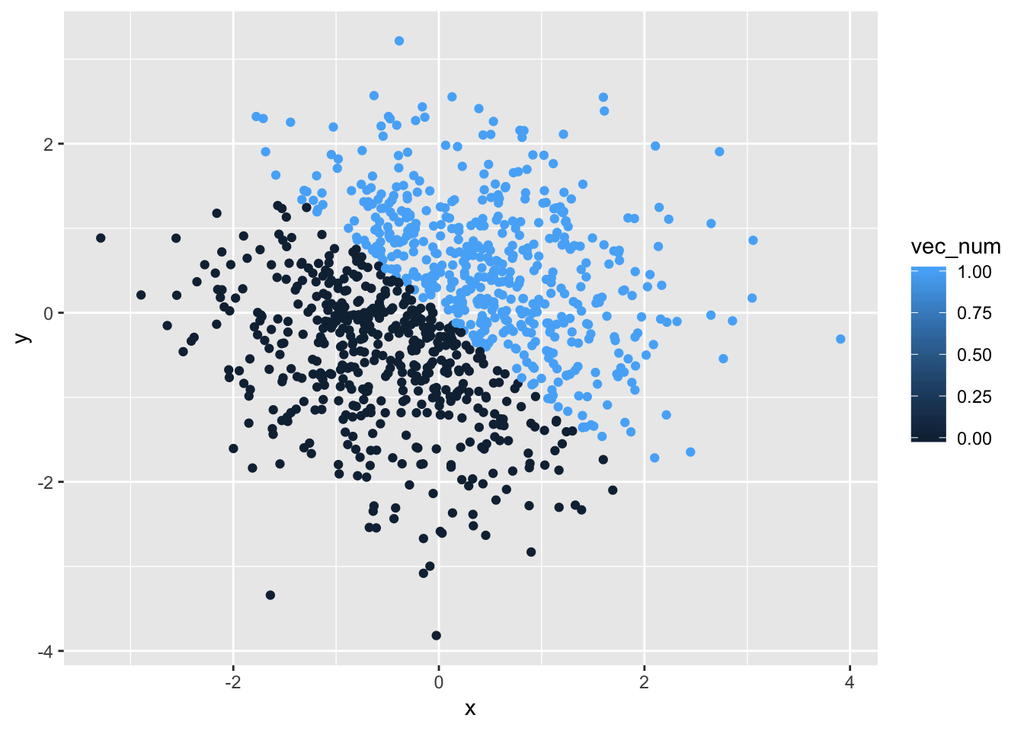

```r
ggplot(prob2_df, aes(x = x, y = y)) +
  geom_point(aes(color = vec_num))
```

Now that the color parameters are numerical, ggplot then create a whole chromatography to describe the color. Although it only has two numerical values `0` and `1`.

- Make a scatterplot of `y` vs `x`, color points using the factor variable.

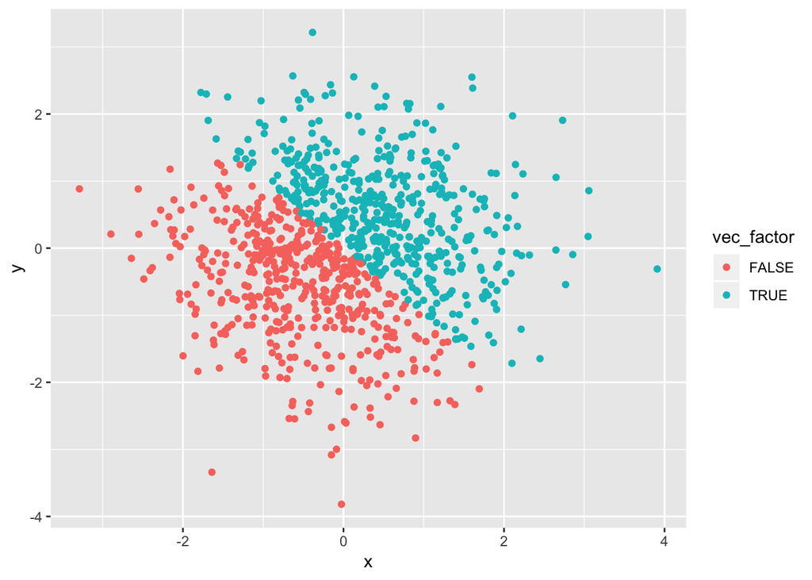

```r
ggplot(prob2_df, aes(x = x, y = y)) +
  geom_point(aes(color = vec_factor))
```

The color parameters only have two factors level, ggplot only assign them with two colors.

### step 5

**Save the image**

```r
ggsave(scat_logical, file = "./scat_logical.pdf")
```